# 2-D Examples

(Many of these examples taken from, or inspired by, [@lazarusa's amazing gallery](https://lazarusa.github.io/gnuplot-examples/gallery/))

# Glowing curves

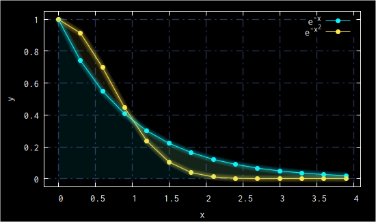

```julia
x = 0:0.3:4
a = exp.(- x)
b =  exp.(- x.^2)
plot(x, a, curveconf = "w lp lw 1 lc '#08F7FE' pt 7 t 'e^{-x}'",
     Axes(object="rectangle from screen 0,0 to screen 1,1 behind fc 'black' fs solid noborder",
          border="lw 1 lc 'white'",
          xtics="textcolor rgb 'white'",
          ytics="textcolor rgb 'white'",
          ylabel="'y' textcolor 'white'",
          xlabel="'x' textcolor 'white'",
          grid="ls 1 lc '#2A3459' dt 4",
          key="t r textcolor 'white'",
          style="fill transparent solid 0.08 noborder"
     )
)
plot!(x, b, curveconf = "w lp lw 1 lc '#FFE64D' pt 7 t 'e^{-x^2}'")
for i in 1:10
       plot!(x,a,w="l lw $(1 + 1.05*i) lc '#F508F7FE' t ''")
       plot!(x,b,w="l lw $(1 + 1.05*i) lc '#F5FFE64D' t ''")
end
plot!(x, a, curveconf = "w filledcu y=0 lw 1 lc '#08F7FE' t ''")
plot!(x, a, supp= b , curveconf = "w filledcu lw 1 lc '#FFE64D' t ''")
```

# Volcano data

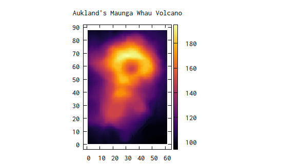

```julia
using RDatasets
volcano = Matrix{Float64}(dataset("datasets", "volcano"))
imagesc(volcano,
        Axes(palette = :inferno,
             auto="fix",
             size="ratio -1",
             title = "\"Aukland's Maunga Whau Volcano\""
         )
)
```

# Animation

An animation can be produced by pushing new plots into an existing plot, and then saving the result as a GIF with the `animate` option.

```julia
closeall()  #hide
t = 0:0.01:2π
f(t,i) = sin.(t .+ i/10)
ac = Axes(title = :Animation, xlabel = :x, ylabel = :y);  # axes configuration
cc = "w l lc 'black' notitle"  # curve configuration
F = plot(t, f(t,1), curveconf = cc, ac);  # create the first frame, with handle 1
for i = 2:50
    pi = plot(t, f(t,i), curveconf = cc, ac, handle=2) # frames, with handle 2
    push!(F, pi)  # push the frame to F
end
save(term = "gif", saveopts = "animate size 600,400 delay 1",
     output="anim.gif", handle=1)
```

[figure not shown]

It is also possible to have a fixed background. The key is to plot the background in every plot. This example plots a "particle" following a sinusoidal, fixed "trajectory":

```julia
x = -5:0.1:5;
y = sin.(π*x);
F = plot(x, y, lc = :black);  # we need one first plot
for (idx, xx) in enumerate(x)
    # plot "trajectory"
    P = plot(x, y, lc = :black, handle = 2);
    # plot! "particle"
    plot!([xx], [y[idx]], w = :points,
          marker = "fcircle", markersize = 3,
          lc = :blue, handle = 2);
    push!(F, P)  # add new frame to first plot
end
# save as gif
save(term = "gif",
     saveopts = "animate size 600,400 delay 1",
     output = "anim.gif", handle = 1)
```

[figure not shown]

# Color from palette

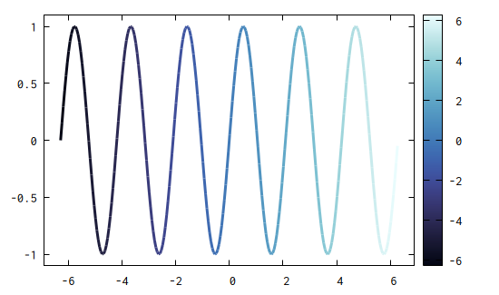

```julia
x = -2π:0.05:2π
plot(x, sin.(3x), supp = x, curveconf = "w l notitle lw 3 lc palette",
     Axes(palette = :ice)
)
```

# Categorical data

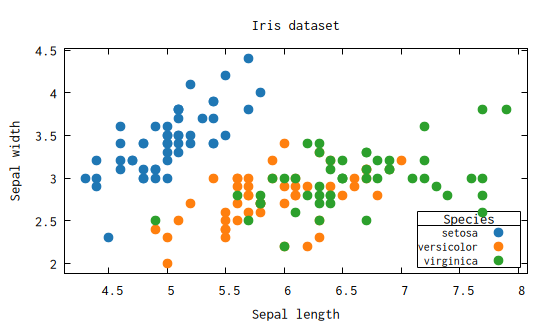

```julia
using RDatasets
dset = dataset("datasets", "iris")
byCat = dset.Species
categ = unique(byCat)
ac = Axes(linetype = :tab10,
          xlabel = "'Sepal length'",
          ylabel = "'Sepal width'",
          auto = "fix",
          title = "'Iris dataset'",
          key = "b r font ',9' tit 'Species' box")
c = categ[1]
indc = findall(x -> x == c, byCat)
p = plot(dset.SepalLength[indc], dset.SepalWidth[indc],
         ac, curveconf = "w p tit '$(c)' pt 7 ps 1.4 ")
c = categ[1]
indc = findall(x -> x == c, byCat)
P = plot(dset.SepalLength[indc], dset.SepalWidth[indc],
         ac, curveconf = "w p tit '$(c)' pt 7 ps 1.4 ");
c = categ[2]
indc = findall(x -> x == c, byCat)
plot!(dset.SepalLength[indc], dset.SepalWidth[indc],
      curveconf = "w p tit '$(c)' pt 7 ps 1.4 ");
c = categ[3]
indc = findall(x -> x == c, byCat)
plot!(dset.SepalLength[indc], dset.SepalWidth[indc],
      curveconf = "w p tit '$(c)' pt 7 ps 1.4 ");
P
```

# Vector fields (arrow plots)

Vector fields can be plotted with the `vectors` plot style. The arrows' `x` and `y` coordinates need to be specified in supplementary columns.

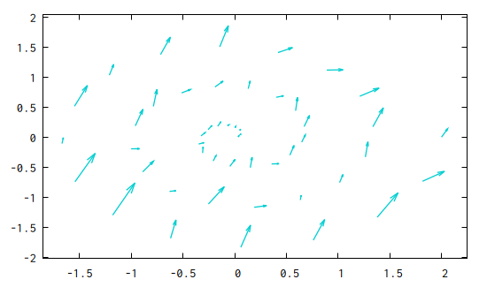

```julia
x = range(0, 6π, length = 50)
A = range(0, 2, length = 50)
xdelta = A./7.0.*rand(50)
ydelta = A./3.0.*rand(50)
plot(A.*cos.(x), A.*sin.(x), supp = [xdelta ydelta], w = :vectors, lc = "'dark-turquoise'")
```

# Violin plots

A violin plot is created by plotting `(y, x)` instead of `(x, y)`, using the `filledcurves` style, and mirroring the plot.

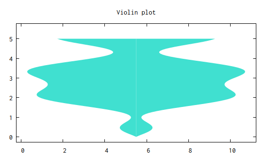

```julia
x = range(0, 5, length=100)
y = 2cos.(x) + sin.(2x) + 0.5cos.(3x) - sin.(4x) .+ 3
M = maximum(y)
plot(y, x, w = "filledcurves x = $M", lc = :turquoise,
     Axes(title = "'Violin plot'"))
plot!(-y .+ 2M, x, w = "filledcurves x = $M", lc = :turquoise)
```

Violin plot with a superimposed boxplot:

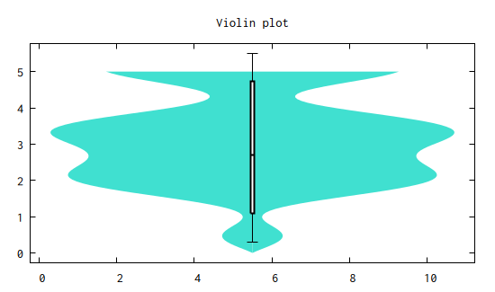

```julia
plot(y, x, w = "filledcurves x = $M", lc = :turquoise,
     Axes(title     = "'Violin plot'",
          style     = "fill solid bo -1",
          boxwidth  = 0.075,
          errorbars = "lt black lw 1"))
plot!(-y .+ 2M, x, w="filledcurves x = $M", lc=:turquoise)
plot!(x, y, w = "boxplot", u = "($M):2", fc = :white, lw = 2)
```

# Plotting times/dates

The key to plotting dates and times is converting them to strings, and then telling gnuplot what the format is, using `timefmt`. In Julia, dates and times are defined in module `Dates`. This example is inspired by [this gnuplot demo](http://gnuplot.sourceforge.net/demo_5.2/timedat.html).

[figure not shown]

```julia
using Dates
dates = [DateTime(2013,6,1,0,0),
                DateTime(2013,6,10,9,30),
                DateTime(2013,6,18,13,05),
                DateTime(2013,7,4,20,35),
                DateTime(2013,7,13,17,18)]
concentrations = [0.2, 0.3, 0.5, 0.38, 0.18]
x = Dates.format.(dates, "dd/mm/yy HHMM")
plot(x, values, u = "1:3",
     Axes(xdata   = "time",
          timefmt = "'%d/%m/%y %H%M'",
          style   = "data fsteps",
          format  = "x \"%d/%m\\n%H:%M\"",
          xlabel  = "\"Date\\nTime\"",
          ylabel  = "\"Concentration\\nmg/l\"",
          title   = "'Plot with date and time as x-values'",
          key     = "right"))
plot!(x, values, u="1:3", w=:p, marker="esquare", legend = "'Total P'")
```

# Displaying a flag with a colored array

This example shows how one can use `set palette defined` to associate particular colors with numerical values. Note that arbitrary colors can be associated with arbitrary numerical values. This example creates the French flag:

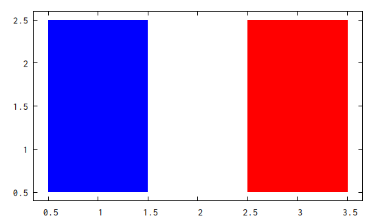

```julia
imagesc([0 0.5 1 ; 0 0.5 1],
        Axes(palette="defined (0 'blue', 0.5 'white', 1 'red')",
             colorbox=:off))
```